# Predicting Proper Execution of Unilateral Dumbbell Biceps Curl

Rooney I.

3/23/2021

```r
knitr::opts_chunk$set(echo = TRUE)
library(parallel)
library(doParallel)
library(caret)
library(ggplot2)
library(cowplot)
```

## Abstract

Using devices such as Jawbone Up, Nike FuelBand, and Fitbit it is now possible to collect a large amount of data about personal activity relatively inexpensively. These type of devices are part of the quantified self movement – a group of enthusiasts who take measurements about themselves regularly to improve their health, to find patterns in their behavior, or because they are tech geeks. One thing that people regularly do is quantify how much of a particular activity they do, but they rarely quantify how well they do it.

In this project, we are using data from accelerometers on the belt, forearm, arm, and dumbell of six participants. They were asked to perform barbell lifts correctly and then incorrectly in 4 different ways.

Fitting a *random forests* classification model to the resulting data results in a model that can accurately predict whether a dumbbel lift is being done correctly or incorrectly (and which type of error is being made) with over 99% accuracy.

## Data Processing

### Data Cleaning

The initial data set consited of a matrix with 159 features and one response. Review of the data showed that many of the columns are sparsely populated. Additionally, there were several timestamp and subject identification features that would not be used for prediction. These columns, and the sparsely populated columns, were eliminated for the training and testing datasets.

```r
# Read-in data and convert
pml.train <- read.csv("pml-training.csv")
pml.train$classe <- as.factor(pml.train$classe)
t.rows <- nrow(pml.train) # number of observations
del.cols <- c(1:7) # Delete the first 7 columns; these are ID & timestamps
# Iterate through columns, if more than 90% are blank or NAs, add to deletion list
for (i in 8:ncol(pml.train)) {
    emptys <- sum(is.na(pml.train[,i]) | pml.train[,i]=="")
    if (emptys/t.rows > 0.90) del.cols <- append(del.cols,i)
}
# Remove columns identified for deletion
pml.train <- pml.train[,-del.cols]
```

### Data Partitioning

The pre-processing resulted in a `19622 x 53` data table (19,622 observations across 52 features and one response). We partitioned this data frame into a training set (approx. 75% of the observations) and a testing set.

```r
set.seed(847)
in.train <- createDataPartition(y=pml.train$classe, p=0.75, list=FALSE)
training <- pml.train[in.train,] # Remove ID & other vars with sparse data
testing  <- pml.train[-in.train,]
```

### Exploratory Data Analysis

Fifty-two predictors is a significant number and does not lend itself to exploration through individual plots. In any case, it is unlikely any single one of the individual plots would yield interesting results.

To get a sense of the variability of the data across it’s fifty-two dimensions we performed Principal Components Analysis on the training data to see if we could account for the variability through only a few principal components.

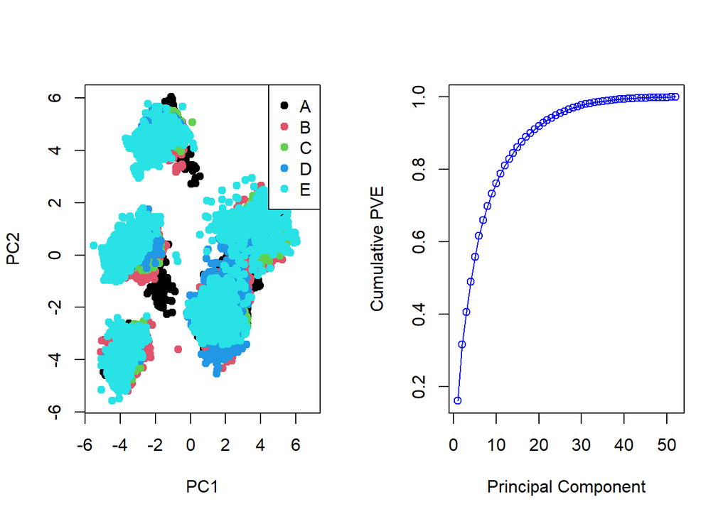

FIGURE 1.1: Principal Component Results

```r
pr.out <- prcomp(training[,-53], scale=TRUE)
par(mfrow=c(1,2))
plot(pr.out$x[,1:2], col=training$classe, pch=19, xlab="PC1", ylab="PC2")
legend("topright", legend=levels(training$classe), pch=19, col=unique(training$classe))
plot(summary(pr.out)$importance[3,], type="o",
     ylab="Cumulative PVE", xlab="Principal Component", col="blue")
```

As can be seen in Figure 1-1, on the left the plot of the first two principal components does reveal five clusters however each cluster includes all of the responses making these two components unsuitable as the sole basis of classification. This makes sense, as the diagram on the first shows that we do not account for 95% of the variability in the data until we reach twenty-five principal components. Twenty five principal components does not significantly simplify our model and would introduce increased model complexity. We elect to conduct further modeling using all fifty-two features.

## Modeling

We are trying to solve a multiple-response (>2) classification problem using a group of continuous and discrete predictors. We will consider two modeling approaches that are good with this type of prediction (one simple and one complex):

1. *Linear Discriminant Analysis*
2. *Random Forests*

### Linear Discriminant Analysis (LDA)

In *LDA* we model the distribution of the predictors X separately in each of the response classes (i.e. given Y ), and then use Bayes’ theorem to flip these around into estimates for Pr(Y = k|X = x). Using *LDA* to predict the *class* using all predictors results in the following confusion matrix:

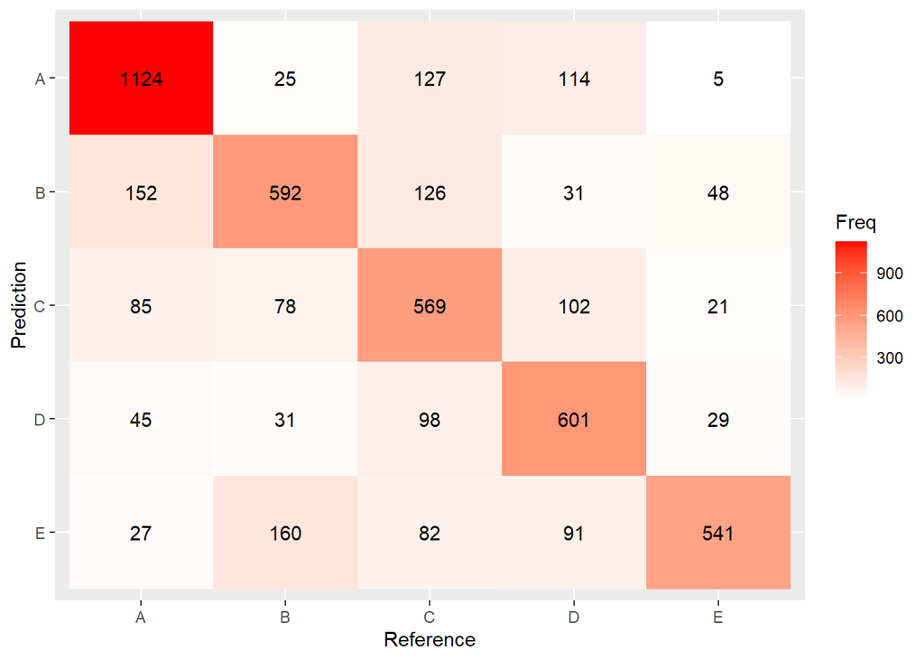

FIGURE 2.1: Linear Discriminant Analysis

```r
fit.lda <- train(classe ~ ., data=training, method="lda")
pred.lda <- predict(fit.lda, newdata=testing[,-53])
cm.lda <- confusionMatrix(pred.lda, testing$classe, dnn=c("Prediction","Reference"))
g.lda <- ggplot(as.data.frame(cm.lda$table),
               aes(Prediction,sort(Reference, decreasing=TRUE), fill=Freq)) +
  geom_tile() +
  geom_text(aes(label=Freq)) +
  scale_fill_gradient(low="white", high="red") +
  labs(x = "Reference", y="Prediction") +
  scale_x_discrete(labels=c("A","B","C","D","E")) +
  scale_y_discrete(labels=c("E","D","C","B","A"))
g.lda
```

In Figure 2.1 We can see that there is some strong prediction accuracy along the diagonal using *LDA* to cross-validate against our testing set. But there are also a significant number of mis-classifications using this model. Our overall accuracy on the testing set using *LDA* is about **70%**. This is too low so we will pursue a more complex approach next.

### Random Forests

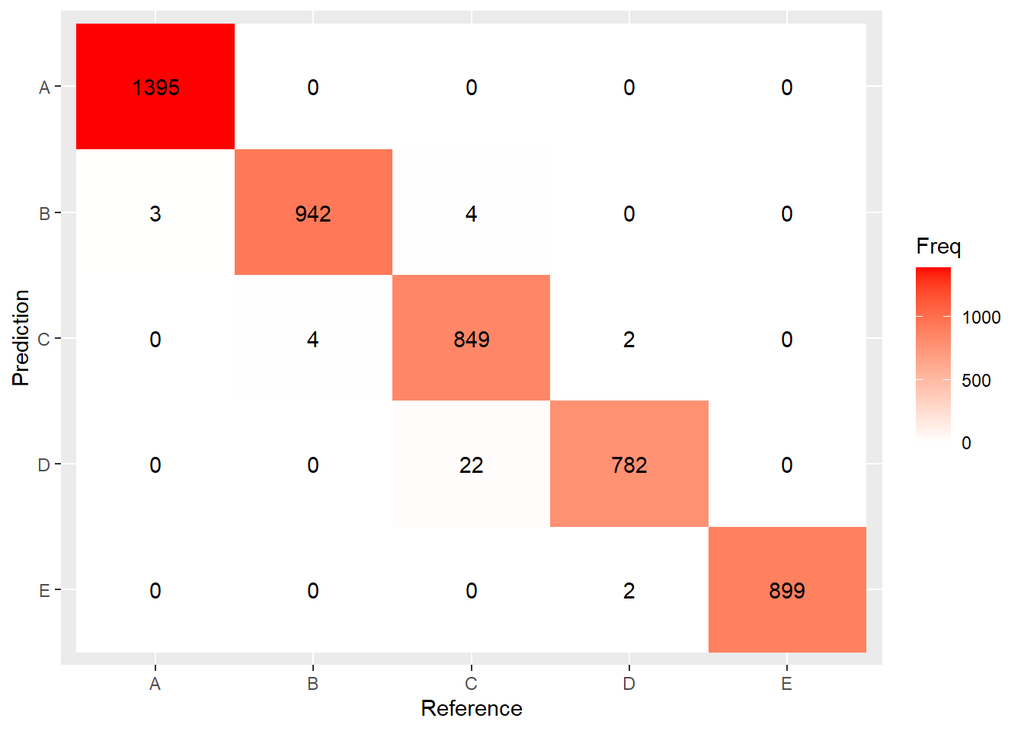

FIGURE 2.2: Random Forests

```r
fit.control <- trainControl(method="cv", number=3, allowParallel=TRUE)
cluster <- makeCluster(detectCores()-1)
registerDoParallel(cluster)
fit.rf  <- train(classe ~ ., data=training, method="rf", trControl=fit.control)
stopCluster(cluster)
registerDoSEQ()
pred.rf <- predict(fit.rf, newdata=testing[,-53])
cm.rf <- confusionMatrix(pred.rf, testing$classe, dnn=c("Prediction","Reference"))
g.rf <- ggplot(as.data.frame(cm.rf$table),
          aes(Prediction,sort(Reference, decreasing=TRUE), fill=Freq)) +
        geom_tile() +
        geom_text(aes(label=Freq)) +
        scale_fill_gradient(low="white", high="red") +
        labs(x = "Reference", y="Prediction") +
        scale_x_discrete(labels=c("A","B","C","D","E")) +
        scale_y_discrete(labels=c("E","D","C","B","A"))
g.rf
```

The confusion matrix pictured in Figure 2.2 shows significantly improved accuracy for this model when cross-validated on the testing set. In fact, we are over **99%** accurate using this model on our testing set.

## Conclusion

Cross-validation against a validation set with *Random Forests* modeling indicates it provides exceptionally good accuracy classifying the class of the exercise based on the 52 input features from the sensor equipment. We expect close to **99%** accuracy with this model for new, out-of-sample data.

The github reposity containing the R markdown file and the supporting files can be reached at https://github.com/RoonDog20/practicalmachinelearning